# Ch1_models_caribou

Erin Tattersall

April 27, 2018

Based on model selection comparison of underlying distributions and zero-inflation, I chose an nbinom1 distribution for caribou data (see Ch1_caribou_modelDistribution.Rmd)  
Here I will:  
1. Select random effects to model random structure  
2. Build models with environmental covariates only  
3. Build hypothesis models with line covariates + environmental  
4. Perform model selection with AIC  
5. Calculate evidence ratios (AICwt of Best Model/ AICwt of other models)  
6. Checking residuals of Top Model 7. Model Averaging? 8. Standardize parameter estimates for easy interpretation

## Finding random structure

```
##        dLogLik dAIC df weight
## r2      6.7     0.0 12 0.844
## rSite   3.7     3.9 11 0.117
## rMonth  2.4     6.6 11 0.031
## r0      0.0     9.3 10 0.008
```

Continue modelling with 2 random effects

## Environmental models

| Model Name | Covariates |
| --- | --- |
| E1 | None |
| E2 | low1750 + SnowDays |
| E3 | low1750 |
| E4 | SnowDays |

```
##    dLogLik dAIC df weight
## E2 21.7     0.0 6  0.968
## E3 17.3     6.8 5  0.032
## E4  4.7    31.9 5  <0.001
## E1  0.0    39.4 4  <0.001
```

Continue modelling Line characteristics with both environmental variables

## Line characteristics

| Model Name | Covariates |
| --- | --- |
| L1 | Treatment + low1750 + SnowDays |
| L2 | VegHt + low1750 + SnowDays |
| L3 | LD1750 + low1750 + SnowDays |
| L4 | LineWidth + low1750 + SnowDays |
| L5 | Treatment + LineWidth + low1750 + SnowDays |
| L6 | LineWidth + VegHt + low1750 + SnowDays |
| L7 | Treatment + LD1750 + low1750 + SnowDays |
| L8 | LD1750 + VegHt + low1750 + SnowDays |
| L9 | Treatment + VegHt + low1750 + SnowDays |
| L10 | Treatment + LineWidth + VegHt + low1750 + SnowDays |
| L11 | Treatment + LineWidth + LD1750 + low1750 + SnowDays |
| L12 | Treatment + VegHt + LD1750 + low1750 + SnowDays |
| L13 | LineWidth + VegHt + LD1750 + low1750 + SnowDays |
| L14 | Treatment + LineWidth + LD1750 + VegHt + low1750 + SnowDays |

```
##     dLogLik dAIC df weight
## L9  39.9     0.0 10 0.152
## L5  39.7     0.4 10 0.124
## L12 40.7     0.5 11 0.121
## L2  36.6     0.8 7  0.105
## L8  37.6     0.8 8  0.104
## L11 40.5     0.9 11 0.096
## L10 40.4     1.0 11 0.091
## L14 41.2     1.5 12 0.073
## L4  35.9     2.1 7  0.054
## L13 37.6     2.7 9  0.040
## L6  36.6     2.7 8  0.039
## L7  27.3    25.2 10 <0.001
## L1  26.1    25.6 9  <0.001
## L3  23.2    27.4 7  <0.001
## E2  21.7    28.5 6  <0.001
## E3  17.3    35.4 5  <0.001
## E4   4.7    60.4 5  <0.001
## E1   0.0    67.9 4  <0.001
```

Calculating evidence ratios (AIC wt of best model/AIC weight of others) gives:

[output not shown]

```
##  Family: nbinom1  ( log )
## Formula:
## Caribou ~ Treatment + VegHt + low1750 + SnowDays + (1 | Site) +
##     (1 | Month)
## Data: det
##
##      AIC      BIC   logLik deviance df.resid
##    536.6    583.9   -258.3    516.6      823
##
## Random effects:
##
## Conditional model:
##  Groups Name        Variance Std.Dev.
##  Site   (Intercept) 0.6684   0.8176
##  Month  (Intercept) 0.1824   0.4271
## Number of obs: 833, groups:  Site, 58; Month, 12
##
## Overdispersion parameter for nbinom1 family (): 1.08
##
## Conditional model:
##                   Estimate Std. Error z value Pr(>|z|)
## (Intercept)       -7.87468    1.57728  -4.993 5.96e-07 ***
## TreatmentHumanUse -0.25850    0.63064  -0.410 0.681882
## TreatmentNatRegen -1.26057    1.16803  -1.079 0.280485
## TreatmentSPP       0.69872    0.52110   1.341 0.179962
## VegHt             -0.33597    0.40894  -0.822 0.411323
## low1750            8.54675    1.84862   4.623 3.78e-06 ***
## SnowDays          -0.05738    0.01506  -3.811 0.000139 ***
## ---
## Signif. codes:  0 '***' 0.001 '**' 0.01 '*' 0.05 '.' 0.1 ' ' 1
```

## Checking Residuals of Top model

### Calculating Overdispersion statistic:

```
##         dsq           n        disp
## 360.9672581 823.0000000   0.4385993
```

According to a nbinom1 distribution, the response variable is not overdispersed

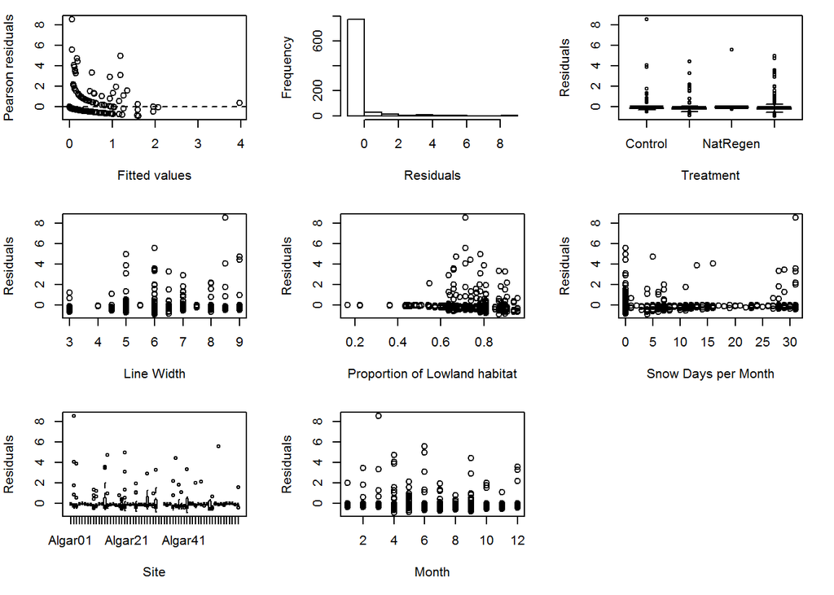